# Final Presentation

6-10-20

```
## lattice theme set by effectsTheme()
## See ?effectsTheme for details.
```

## Research Question

Scientisits collected data on a variety of children's attributes, including gender, age, social deficit scores, intelligence score, handedness, and balance, dexterity, catching, & throwing abilities, which were aggregated to create a movement score.

In looking at this data, we are interested in determing whether their is relationship between social deficit scores and movement ability, especially in regards to children with ADHD and autism.

## The Data

Here are the demographics of our participants after filtering out repeat visits, other duplicates, and troublemakers:

```
    TypDev, ADHD, Autism
    63,     45,   25    Female
    170,    112,  118   Male
```

And here is a preliminary visual of the relationship between social deficits and movement ability:

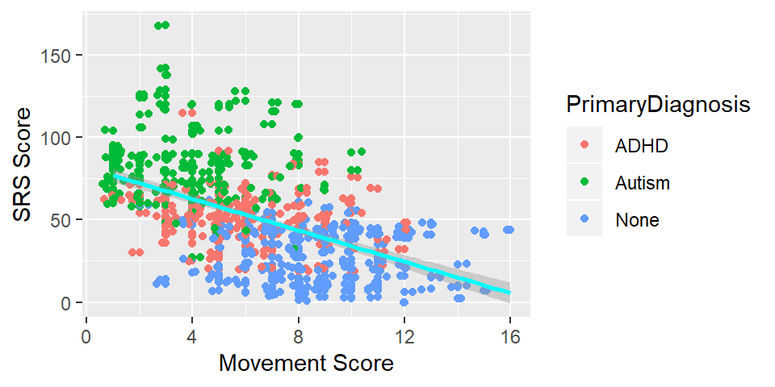

## The Secret Influencer: SRS Version

The two versions of the social deficit test were not consistent with one another neither in general nor for the individual primary diagnosis groups, especially typically developing. From here on, we will stratify the data by test version.

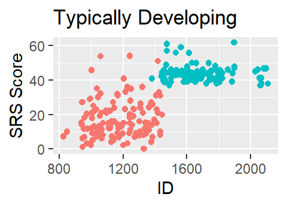

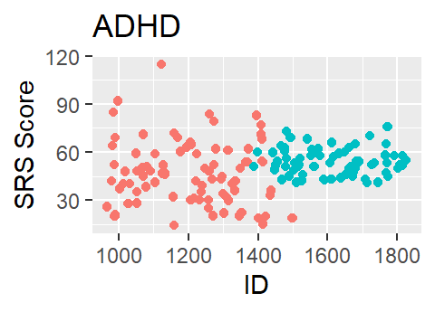

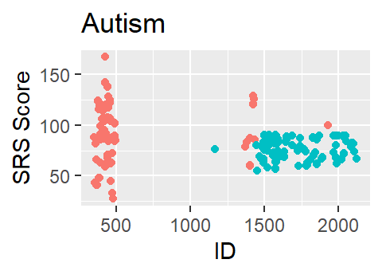

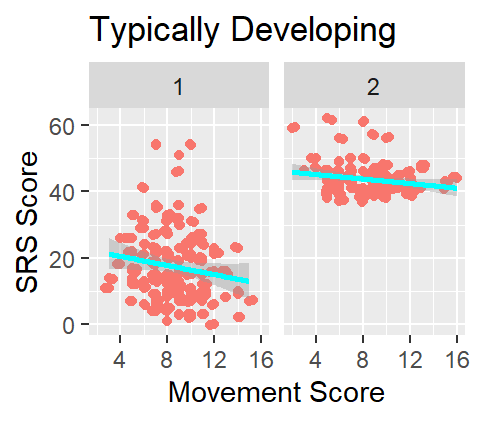

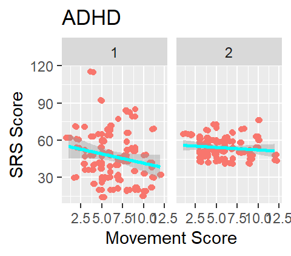

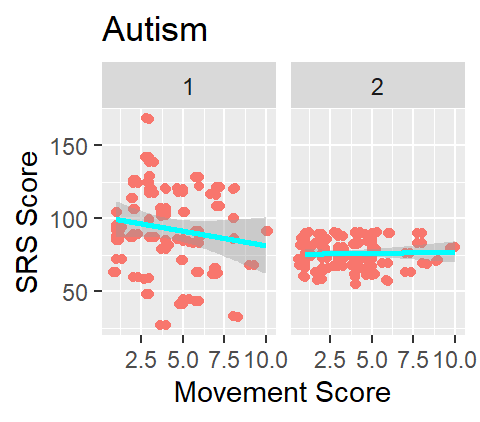

## Controlling for Age and Sex

The differences between sexes in terms of social deficits is minimal. Social deficit scores don't really change with age and movement scores increase with age.

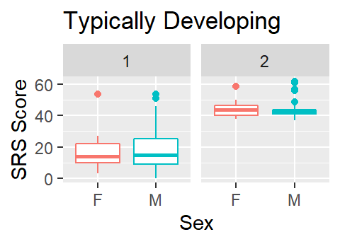

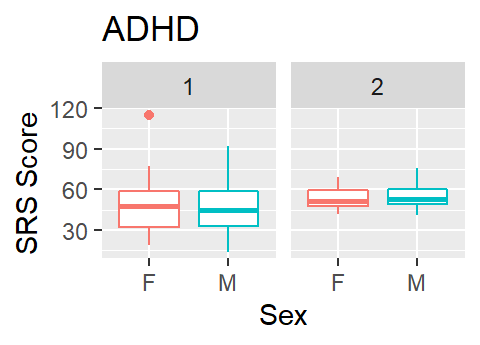

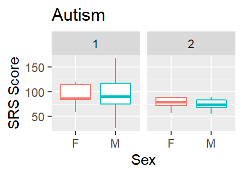

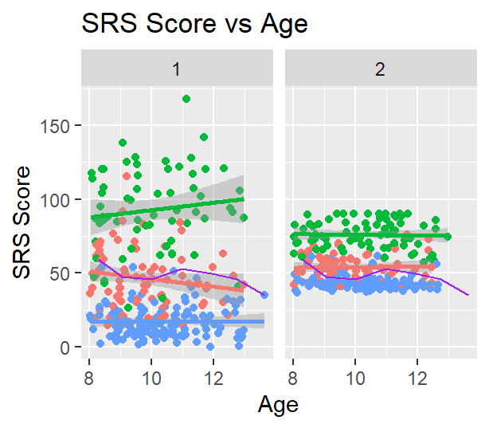

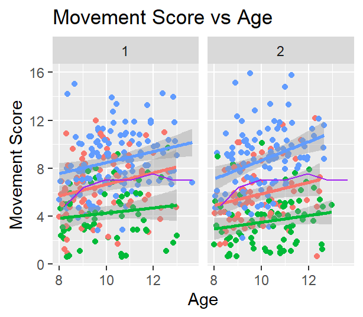

## Controlling for Other Variables

Secondary Diagnosis (red = no, blue = yes)

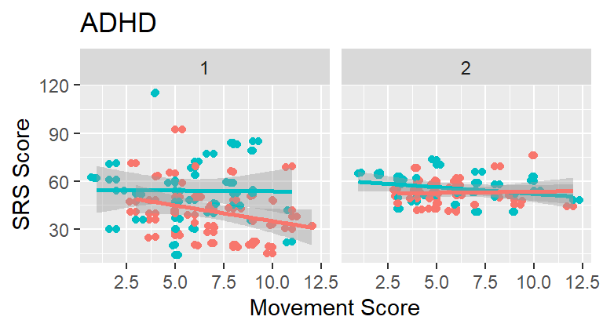

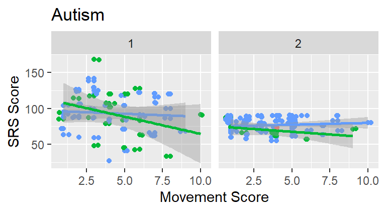

ADHD Subtype (red = combined, blue = inattentive, green = hyperactive/impulsive)

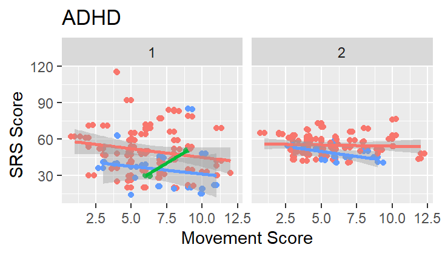

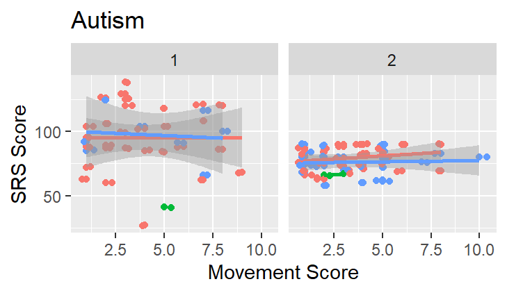

## Typically Developing Model

```r
typModel <- lm(SRS_TotalRawScore ~ mABC_TotalStandardScore * SRS_VERSION - 1, typ)
```

```
## [1] "Adjusted R Squared: 0.703, F Test's P Value: 0"
```

```
## [1] "Version 1 Beta Estimates: y = 23.3 + -0.689x"
```

```
## [1] "Version 2 Beta Estimates: y = 46.6 + -0.345x"
```

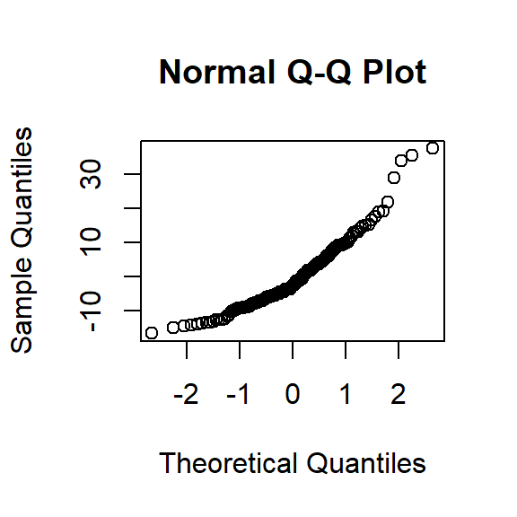

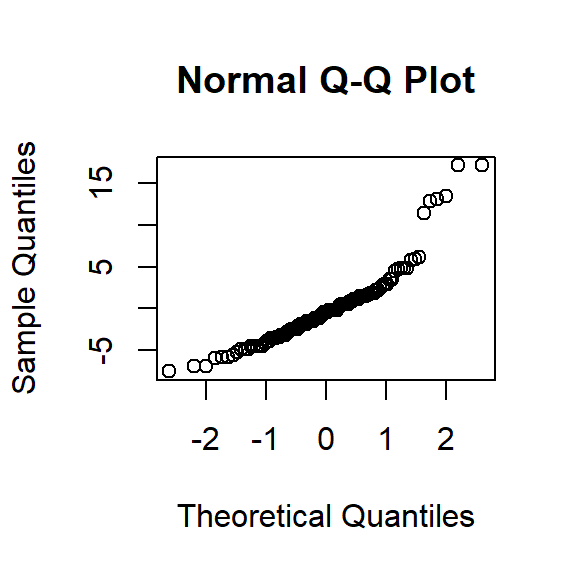

## Checking Assumptions

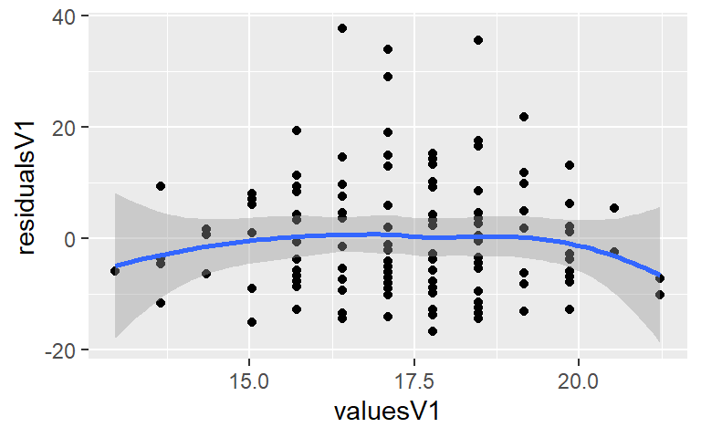

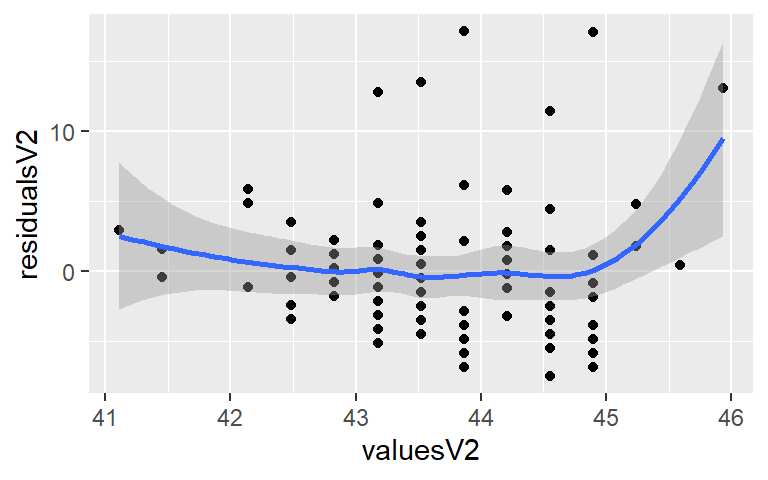

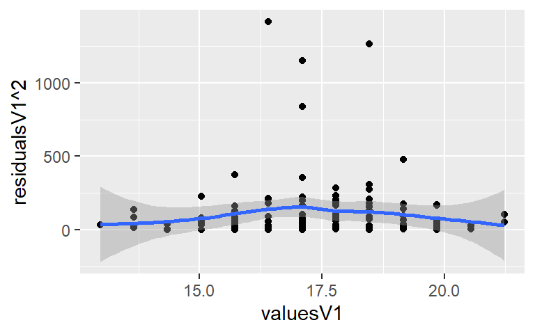

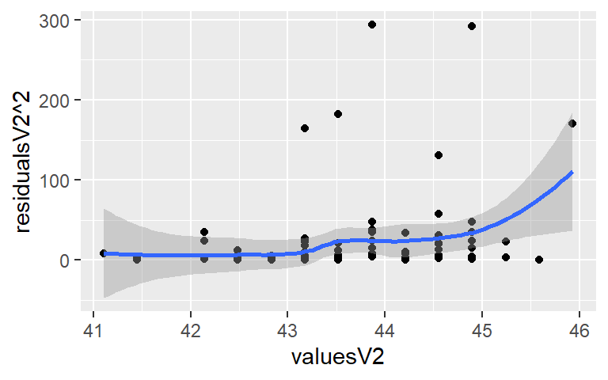

## ADHD Model

```r
adhdModel <- lm(SRS_TotalRawScore ~ mABC_TotalStandardScore * SRS_VERSION
                + SecondaryDiagnosis + ADHD_Subtype - 1, adhd)
```

[output not shown]

```
## [1] "Version 1 Beta Estimates: y = 53.4 + -1.106x"
```

```
## [1] "Version 2 Beta Estimates: y = 54.7 + -0.338x"
```

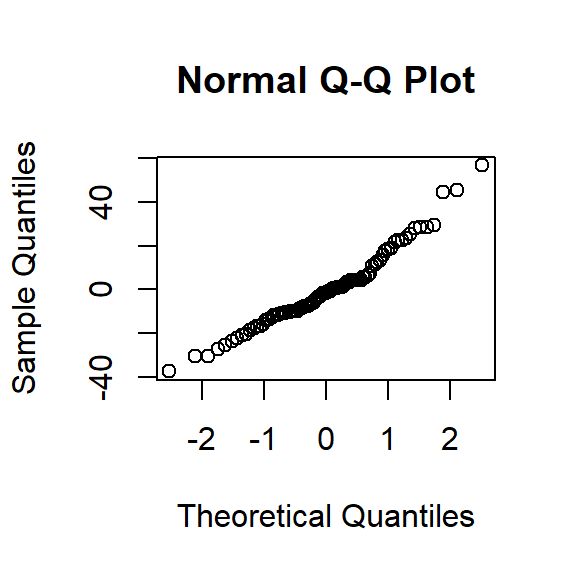

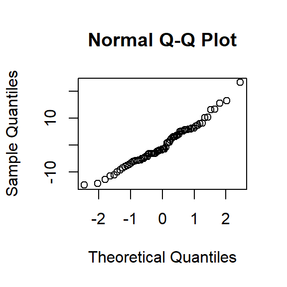

## Checking Assumptions

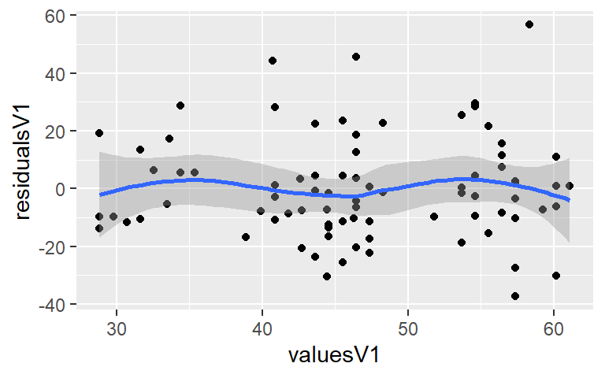

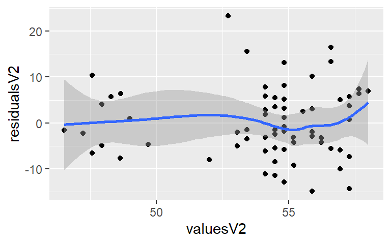

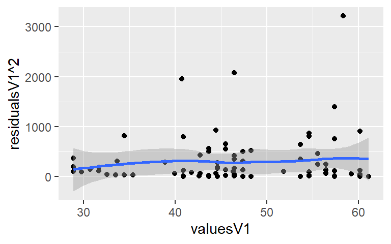

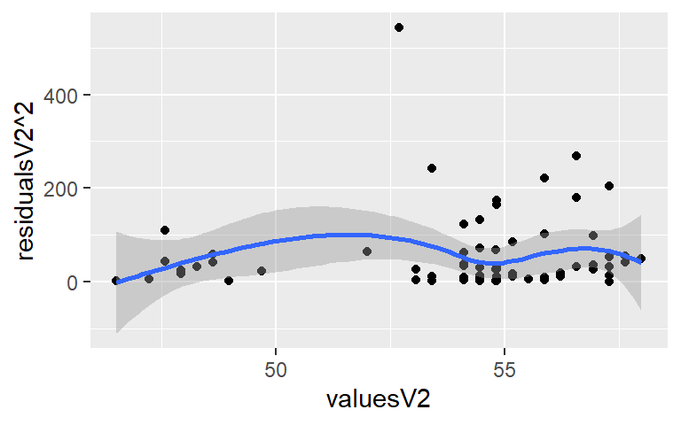

## Autism Model

```r
autismModel <- lm(SRS_TotalRawScore ~ mABC_TotalStandardScore * SRS_VERSION
                  + SecondaryDiagnosis - 1, autismWithSecond)
```

[output not shown]

```
## [1] "Version 1 Beta Estimates: y = 98.9 + -1.96x"
```

```
## [1] "Version 2 Beta Estimates: y = 72.4 + 0.162x"
```

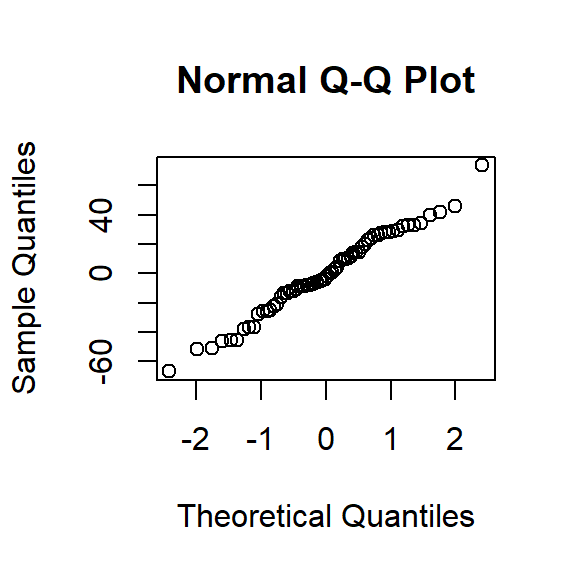

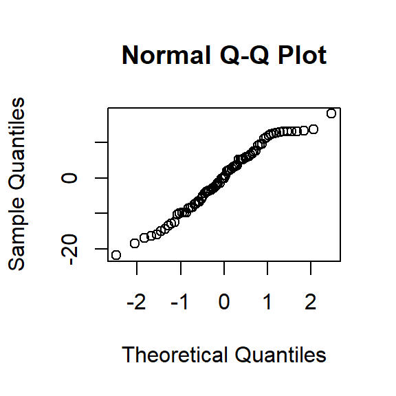

## Checking Assumptions

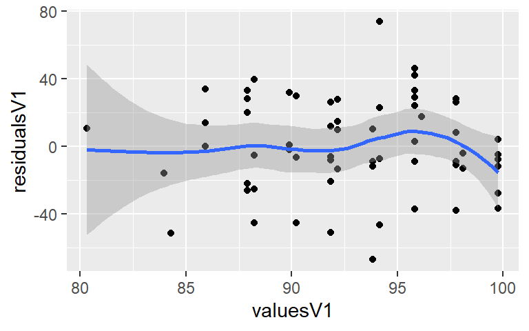

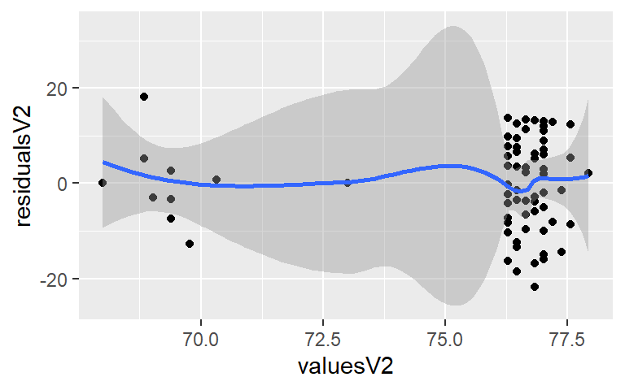

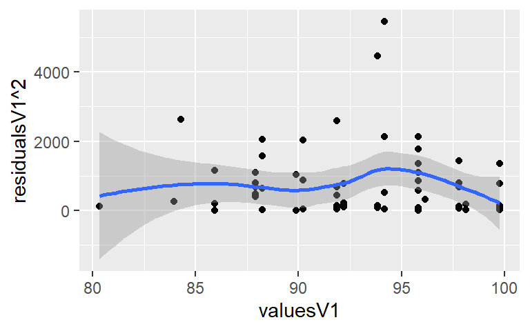

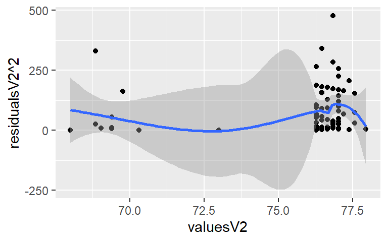

## Comparing Beta Estimates

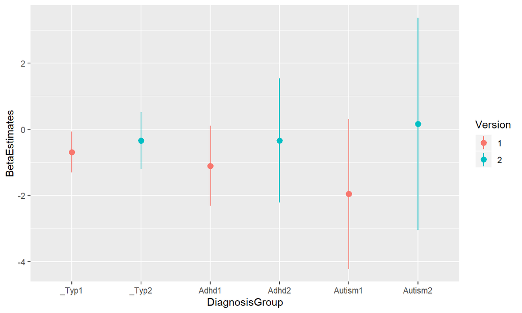